# House Prices: Advanced regression techniques

# Introduction

The aim of this notebook is to predict sales prices and practice feature engineering, RFs and gradient boosting. There are three files given, that include - train.csv, test.csv, and sample_submission.csv. The sample_submission.csv is a bechmark submission from a linear regression on year and month of sale, lot of square footage, and number of bedrooms.

# Structure of the data

The housing data has 1460 rows and 81 columns with the target feature Sale price.

```r
dim(train)
```

```
[1] 1460   81
```

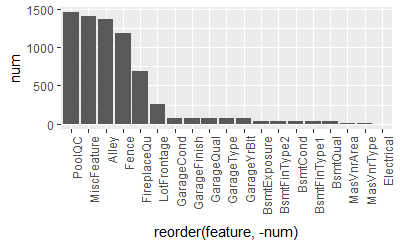

```r
df = setDT(as.data.frame(colSums(sapply(train,is.na))),keep.rownames = TRUE)
colnames(df)<-c("feature","num")
ggplot(data=df[num !=0,,],aes(x=reorder(feature,-num),y=num)) +
  geom_bar(stat="identity") +
  theme(axis.text.x = element_text(angle=90,hjust =1))
```

The top five categorical values with the largest missing values include

- poolQC: indicates the pool quality
- miscFeatures:indicates the miscellaneous features not covered by the other categories
- alley: indicates the type of alley access
- fence: indicates the fence quality
- fireplacesQu: indicates the number of fireplaces

The missing value indicates the majority of houses don’t have alley access, no fence, or no fireplace, or other features that are covered by the MiscFeatures.

## Categorical values that are of character type

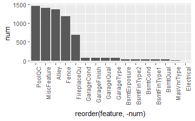

```r
train = as.data.table(train)
df = setDT(as.data.frame(colSums(sapply(train[,.SD, .SDcols=cat_var],is.na))),keep.rownames = TRUE)
colnames(df)<-c("feature","num")
ggplot(data=df[num !=0,,],aes(x=reorder(feature,-num),y=num)) +
  geom_bar(stat="identity") +
  theme(axis.text.x = element_text(angle=90,hjust =1))
```

## Catergorical values that are of numeric type

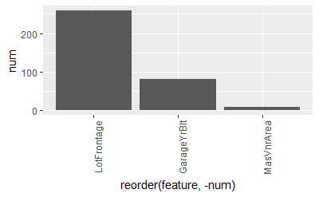

```r
train = as.data.table(train)
df = setDT(as.data.frame(colSums(sapply(train[,.SD, .SDcols=numeric_var],is.na))),keep.rownames = TRUE)
colnames(df)<-c("feature","num")
ggplot(data=df[num !=0,,],aes(x=reorder(feature,-num),y=num)) +
  geom_bar(stat="identity") +
  theme(axis.text.x = element_text(angle=90,hjust =1))
```

## Visualisation for the missing data

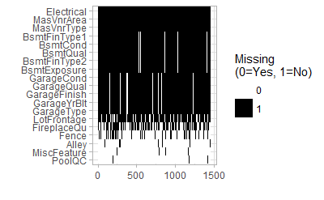

```r
plot_Missing <- function(data_in, title = NULL){
  temp_df <- as.data.frame(ifelse(is.na(data_in), 0, 1))
  temp_df <- temp_df[,order(colSums(temp_df))]
  data_temp <- expand.grid(list(x = 1:nrow(temp_df), y = colnames(temp_df)))
  data_temp$m <- as.vector(as.matrix(temp_df))
  data_temp <- data.frame(x = unlist(data_temp$x), y = unlist(data_temp$y), m = unlist(data_temp$m))
  ggplot(data_temp) + geom_tile(aes(x=x, y=y, fill=factor(m))) + scale_fill_manual(values=c("white", "black"), name="Missing\n(0=Yes, 1=No)") + theme_light() + ylab("") + xlab("") + ggtitle(title)
}
plot_Missing(train[,colSums(is.na(train)) > 0, with = FALSE])
```

Getting insight on the number of houses that were remodeled.if the YearBuilt date is different from the YearRemodAdd, then the house was remodeled. This can be calculated as follows

```r
print(sum(train[,'YearRemodAdd',with=FALSE] != train[,'YearBuilt',with=FALSE]))
```

```
[1] 696
```

```r
cat('Percentage of houses remodeled',sum(train[,'YearRemodAdd', with = FALSE] != train[,'YearBuilt', with = FALSE])/ dim(train)[1])
```

```
Percentage of houses remodeled 0.4767123
```

```r
cat('Train has', dim(train)[1],'rows and', dim(train)[2],'columns.', '\n')
```

```
Train has 1460 rows and 81 columns.
```

```r
cat('Test has', dim(test)[1],'rows and', dim(test)[2],'columns.', '\n')
```

```
Test has 1459 rows and 80 columns.
```

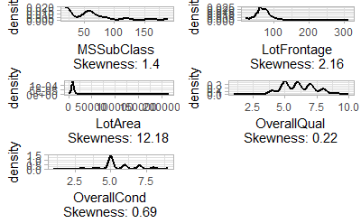

```r
train_cat <- train[,.SD,.SDcols = cat_var]
train_cont <- train[,.SD,.SDcols = numeric_var]
plotHist <- function(data_in, i) {
  data <- data.frame(x=data_in[[i]])
  p <- ggplot(data=data, aes(x=factor(x))) + stat_count() + xlab(colnames(data_in)[i]) + theme_light() +
    theme(axis.text.x = element_text(angle = 90, hjust =1))
  return (p)
}
doPlots <- function(data_in, fun, ii, ncol=3) {
  pp <- list()
  for (i in ii) {
    p <- fun(data_in=data_in, i=i)
    pp <- c(pp, list(p))
  }
  do.call("grid.arrange", c(pp, ncol=ncol))
}
plotDen <- function(data_in, i){
  data <- data.frame(x=data_in[[i]], SalePrice = data_in$SalePrice)
  p <- ggplot(data= data) + geom_line(aes(x = x), stat = 'density', size = 1,alpha = 1.0) +
    xlab(paste0((colnames(data_in)[i]), '\n', 'Skewness: ',round(skewness(data_in[[i]], na.rm = TRUE), 2))) + theme_light()
  return(p)

}
doPlots(train_cont, fun = plotDen, ii = 2:6, ncol = 2)
```

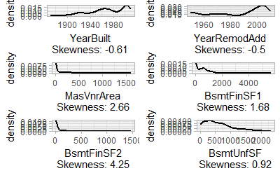

```r
doPlots(train_cont, fun = plotDen, ii = 7:12, ncol = 2)
```

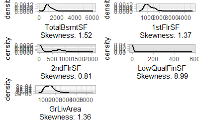

```r
doPlots(train_cont, fun = plotDen, ii = 13:17, ncol = 2)
```

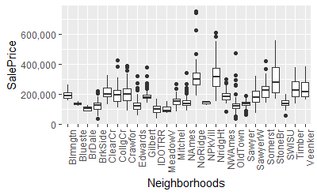

```r
train %>%
  select(Neighborhood, SalePrice) %>%
  ggplot(aes(factor(Neighborhood), SalePrice)) +
  geom_boxplot() +
  theme(axis.text.x = element_text(angle = 90, hjust =1)) +
  xlab('Neighborhoods') +
  scale_y_continuous(labels=scales::comma)
```

# Explore the correlation

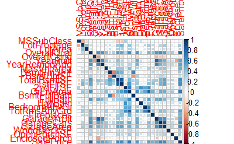

```r
correlations <- cor(na.omit(train_cont[,-1,with=FALSE]))
row_indic <- apply(correlations, 1, function(x) sum(x >0.3 | x < -0.3) >1)
correlations <- correlations[row_indic, row_indic]
corrplot(correlations,method = "square")
```

The correlation matrix shows there are several variables that are strongly and positively correlated with housing price.

- OverallQual
- YearBuilt
- YearRemodAdd
- MasvnrArea
- BsmtFinSF1
- TotalBsmtSF
- 1stFlrSF
- GrLiveArea
- FullBath
- TotRmsAbvGrd
- FirePlaces
- GarageYrBlt
- GarageCars
- GarageArea
- WoodDeskSF
- OpenPorchSF